# GaSP vs. DLM-GaSP for Emulating Temporal Simulators

In this markdown file, I compare the standard Gaussian stochastic process emulation (GaSP) methodology with a dynamic linear model GaSP for emulating and calibrating an expensive computer simulation that outputs a time series. The standard GaSP framework for emulating computer simulators essentially amounts to Gaussian process regression or Kriging, where time along with the calibration parameters are treated as input data. Unfortunately, this methodology (as currently implemented in Stan) quickly becomes infeasible for even moderately-sized time series. I will demonstrate in the following sections with some simulation examples.

# GaSP Background

In this section, I review the (GaSP) emulation methodology to motivate the dynamic model extension in the following section. The literature on GaSP methodology can be broken down into the nonexclusive categories (Higdon et al. 2004):

- experimental design - determining the input settings in which to carry out the expensive computer simulation training runs
- emulation - construct a statistical model for the expensive computer simulator which behaves similarly, enabling new computer inputs to be used
- calibration - using a combination of field observations and training runs, estimate the unknown computer inputs that map to the real-world data or physical system

In the following sub-sections, I focus on emulation and calibration. Though experimental design is certainly important, I have found a naive space-filling design adequate for our simulation purposes.

## Emulation

Let a computer simulation model, $y$, be a function of $d$-dimensional inputs $\mathbf z=(z_1,\ldots,z_d)^\top$ and generate a scalar output, i.e. $y: \mathbb R^d\to\mathbb R$. The purpose of the GaSP methodology is to learn how $y$ behaves for unknown input values $\mathbf{z}^\star$ based on a limited number of $m$ training runs, denoted $\{\mathbf{z}_1,\ldots,\mathbf z_m\}$. The GASP methodology then places a Gaussian process prior on the unknown functional form of $y$ so that
$$y(\cdot) \sim \mathcal{GP}(\mu(\cdot),\sigma^2 c(\cdot,\cdot)),$$
where $\mu,$ $\sigma^2$, and $c(\cdot,\cdot)$ are the mean, variance, and correlation function, respectively. Often the correlation function is assumed to follow a standard parametric form like the squared exponential correlation function
$$c(\mathbf{z},\mathbf{z}')=\exp\big(-\sum_{i=1}^d \beta_i(\mathbf{z}_i-\mathbf{z}_i')^2\big),$$
for any two inputs $\mathbf z, \mathbf z'\in\mathbb R^d$

As before, given $m$ training runs and assuming the GASP emulation framework, then let the collection of training runs be denoted
$$\mathbf{y}_{1:m}:=(y(\mathbf{z}_1),\ldots,y(\mathbf z_m))^\top.$$
Note that $\mathbf y_{1:m}$ is distributed multivariate Gaussian. Therefore, for unknown input point $\mathbf{z}^\star$, the predictive distribution can be formed through considering the joint distribution $p(\mathbf{y}_{1:m},y(\mathbf{z}^\star))$. This joint distribution will be multivariate Gaussian, so applying the standard conditioning identities gives the posterior predictive distribution of $p(y(\mathbf{z}^\star)|\mathbf{y}_{1:m})\sim N(\tilde \mu(\mathbf{z}^\star),\tilde v(\mathbf{z}^\star)),$ with
$$\begin{aligned}
\tilde\mu(\mathbf{z}^\star)&=\boldsymbol\mu+\boldsymbol{\gamma}^\top\boldsymbol\Gamma^{-1}(\mathbf{y}_{1:m}-\boldsymbol\mu) \\
\tilde v(\mathbf{z}^\star)&=\sigma^2(1-\boldsymbol{\gamma}^\top\boldsymbol{\Gamma}^{-1}\boldsymbol{\gamma}),
\end{aligned}$$
where $\boldsymbol{\gamma}=(c(\mathbf{z}^\star,\mathbf{z}_1),\ldots,c(\mathbf{z}^\star,\mathbf{z}_m))^\top$ and $\boldsymbol{\Gamma}_{ij}=c(\mathbf{z}_i,\mathbf{z}_j)$ for $i,j=1,\ldots,m.$ Conceptually, this framework is immediately applicable to emulating computer simulations that output time series, in that $t$ can just be included in the input $\mathbf z$. However, this would massively increase the computational demand, as GP regression is of order $\mathcal{O}(n^3)$, where $n$ is the dimension of input to the GP.

## Calibration

In this sub-section, we follow the approach of (Higdon et al., 2004) in the presentation of the calibration methodology. The calibration framework presented in this work augments the field observations with the simulation runs and constructs the hierarchical model thereafter. To be explicit with the model formulation, let the field observations be denoted $\mathbf y^*$ at some unknown calibration parameters $\mathbf z^*$ to be estimated. Like in the above section, let $\mathbf y$ be the simulation runs at $m$ design points $\{\mathbf z_1,\ldots,\mathbf z_m\}$. Now define the concatenated vector $\mathbf y' := (\mathbf y^*, \mathbf y)^\top$. The likelihood then becomes
$$\mathcal L(\mathbf y'|\mathbf z^*,\mu,\boldsymbol\beta)\propto |\boldsymbol\Sigma|^{-1/2}\exp\Big(-\frac{1}{2}(\mathbf y' - \mu\boldsymbol 1)^\top\boldsymbol \Sigma^{-1}(\mathbf y' - \mu\boldsymbol 1)\Big)$$
where
$$\boldsymbol\Sigma = \boldsymbol\Sigma_{\mathbf y}+\begin{pmatrix}\boldsymbol\Sigma_{\mathbf y^*} & 0 \\ 0 & 0\end{pmatrix}.$$
The matrices $\boldsymbol \Sigma_{\mathbf y}$ + $\boldsymbol \Sigma_{\mathbf y^*}$ are constructed from applying the correlation function mentioned in the above section.

The posterior then takes the form
$$p(\mathbf z^*,\mu,\beta,|\mathbf y_c)\propto \mathcal L(\mathbf y_c|\mathbf z^*,\mu,\boldsymbol\beta)p(\beta)p(\mathbf z^*)p(\mu),$$
and this is all that’s necessary to construct the Bayesian hierarchical model.

# DLM-GaSP Background

In this section, we review the framework developed by (Liu and West, 2009) and applied by (Farah et. al., 201) to emulate and calibrate an expensive epidemic model of A/H1N1 influenza. To alleviate the computational demands of the previous section, a dynamic linear model is introduced to capture the temporal structure, while the GP kernel captures the relation among input parameters, without including the time dimension. Define the following necessary ingredients to build the DLM-GASP methodology:

- $m$ training data points $\mathbf{z}_{1:m}=\{\mathbf{z}_1,\ldots,\mathbf{z}_m\}$, where each $\mathbf z_i\in\mathbb R^d$
- a multivariate time series where at each time slice $t$, the outcome is a vector $\mathbf{y}_t(\mathbf{z}_{1:m})=(\mathbf{y}_t(\mathbf{z}_1),\ldots,\mathbf{y}_t(\mathbf{z}_m))^\top$.

## Emulation

The DLM-GASP framework now uses a flexible time-varying autoregressive model (TVAR) to capture potentially non-stationary and intricate computer simulation outputs that vary over time. For each time series generated from a design point $\mathbf{z}_i$, the univariate TVAR model of order $p$ is written
$$\mathbf{y}_t(\mathbf{z}_i)=\sum_{j=1}^p{\phi}_{t,j} y_{t-j}(\mathbf{z}_i)+{\varepsilon}_t,$$
where the autoregressive parameters $({\phi}_1,\ldots,\phi_p)$ are allowed to vary over time and $\varepsilon_t\sim\mathcal{N}(0,v_t)$. The multiple time series are then linked through a GASP model with covariance function
$$\text{Cov}(\mathbf{z},\mathbf{z}')=v_tc(\mathbf{z},\mathbf{z}').$$
The multivariate TVAR model may then be written compactly as
$$\mathbf y_t(\mathbf{z}_{1:m}) = \mathbf F_t^\top \boldsymbol\phi_t+\boldsymbol\varepsilon_t,$$
where
$$\begin{aligned}
\mathbf F^\top_{t}&=\begin{pmatrix}y_{t-1}(\mathbf{z}_1) & \cdots &y_{t-p}(\mathbf{z}_1)\\ \vdots & \ddots & \vdots \\
y_{t-1}(\mathbf{z}_m) & \cdots &y_{t-p}(\mathbf{z}_m)
\end{pmatrix},
\end{aligned}$$
$\boldsymbol\varepsilon_t\sim N(0,v_t\boldsymbol\Sigma)$ and $\boldsymbol\Sigma$ is the $m\times m$ correlation matrix formed from the GP kernel function. The hidden state of the system is allowed to follow a random walk in that
$$\boldsymbol{\phi}_t=\boldsymbol{\phi}_{t-1}+\boldsymbol{w}_t, \quad \boldsymbol{w}_t\sim \mathcal{N}(0,\mathbf{W}_t).$$

The resulting posterior predictive inference necessary for emulation at an unknown input point $\mathbf{z}^\star$ is then found through standard multivariate Gaussian conditioning arguments to be normal with first two moments specified as
$$\begin{split}
\mu(\mathbf{z}^\star)&=\sum_{j=1}^p\phi_{t,j}\mathbf{y}_{t-j}(\mathbf{z}^\star)+\frac{1}{v_t}\boldsymbol{\gamma}_{\mathbf{z}^\star}^\top\boldsymbol\Sigma^{-1}\boldsymbol{\varepsilon}_t\\
\sigma^2(\mathbf{z}^\star)&= v_t(1-\boldsymbol{\gamma}_{\mathbf{z}^\star}^\top \boldsymbol\Sigma^{-1}\boldsymbol{\gamma}_{\mathbf{z}^\star}),
\end{split}$$
with $\boldsymbol{\gamma}_{\mathbf{z}^\star}=(c(\mathbf{z}^\star,\mathbf{z}_1),\ldots,c(\mathbf{z}^\star,\mathbf{z}_m))^\top$ and $\boldsymbol{\varepsilon}_t=(\varepsilon(\mathbf{z}_1),\ldots,\varepsilon(\mathbf{z}_m))^\top$. With these moments established, it is seen that the DLM-GASP emulator interpolates the training data, while the uncertainty associated with new input values is quantified through the Gaussian posterior predictive distribution.

## Calibration

In most calibration applications that utilize the DLM-GaSP framework, Bayesian modularization is used (Farah et al. 2014). Modularization seeks to improve computational performance of parameter inference with MCMC by breaking up the inference into two stages: the first MCMC run infers the parameters necessary for the emulation step. The second stage uses MCMC to infer the calibration parameters. However, I have found Hamiltonian Monte Carlo powerful enough to not require this modularization step, and in Stan I have implemented fully Bayesian analysis for the DLM-GaSP model. The calibration state for the DLM-GaSP amounts again to Gaussian predictive distribution theory. To see this, consider the two observations models, one for the field data and one for the simulation runs. Let the field data be denoted $\mathbf y^*$ and let the time-varying autoregressive component of the DLM-GaSP model be denoted $M_t(\cdot)$ so that
$$M_t(\cdot)=\sum_{j=1}^p\phi_{t,j}y_{t-j}(\cdot).$$
The two models can be written as
$$\text{Field Data Model: } y^*_t = M_t(\mathbf z^*) + \varepsilon_t(\mathbf z^*) + \varepsilon_{y^*_t} \\
\text{Emulator Model: } \mathbf y_t(\mathbf z_{1:m}) = \mathbf M_t(\mathbf z_{1:m})+\boldsymbol\varepsilon(\mathbf z_{1:m}),$$
where $\mathbf M_t(\mathbf z_{1:m}):=(M_t(\mathbf z_1),\ldots,M_t(\mathbf z_m))^\top$, $\varepsilon_{y^*_t}\sim N(0,\sigma_{y^*}^2)$, and $\varepsilon_t(\mathbf z^*)\sim N(0,v_t)$.

Now conditioning on the model parameters, $\boldsymbol\xi_t$, and training runs, $\mathbf y$, forming the conditional $p(\mathbf y^*|\boldsymbol \xi_{t},\mathbf y)$ will give a Gaussian distribution following standard Gaussian conditioning identities. To be explicit,
$$p(y_t^*|\mathbf y_t,\boldsymbol \xi_t) \sim \mathcal N(\mathbb M_t(\mathbb z^*), \mathbb S_t(\mathbb z^*)),$$
where $\mathbf M_t(\mathbf z^*) + \mathbf r^\top(\mathbf z^*)\Sigma^{-1}(\mathbf y-\mathbf M_t(\mathbf z_{1:m}))$, $\mathbb S_t(\mathbf z^*):=(\sigma^2_{y^*}+v_t)+v_t\mathbf r^\top(\mathbf z^*)\Sigma^{-1}r(\mathbf z^*)$ and $\mathbf r(\mathbf z^*) := (c(\mathbf z^*,\mathbf z_1),\ldots,c(\mathbf z^*,\mathbf z_m))^\top$. This follows since for Gaussian $X$ and $Y$, the identities hold:
$$\mathbb E[Y|X=x]=\mathbb E(Y)+\Sigma_{YX}\Sigma^{-1}_X(x-\mathbb E(X))\\
\Sigma_{Y|X}=\Sigma_Y-\Sigma_{YX}\Sigma_X^{-1}\Sigma_{YX}^\top.$$

This will be essentially all I need to code up the likelihood necessary for joint emulation-calibration in Stan.

# Experiments: GaSP versus DLM-GaSP

## Training Runs

### Training Runs for GaSP Model

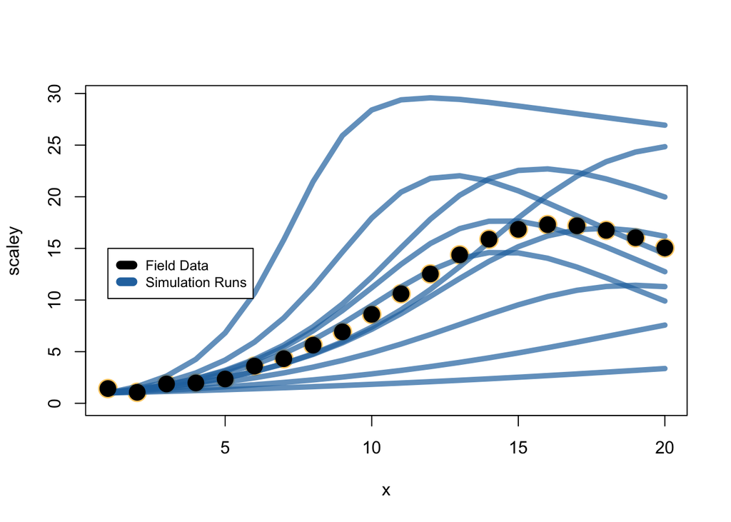

In the following draws, the true data-generating parameters are shown as a vertical $\color{red}{red}$ line.

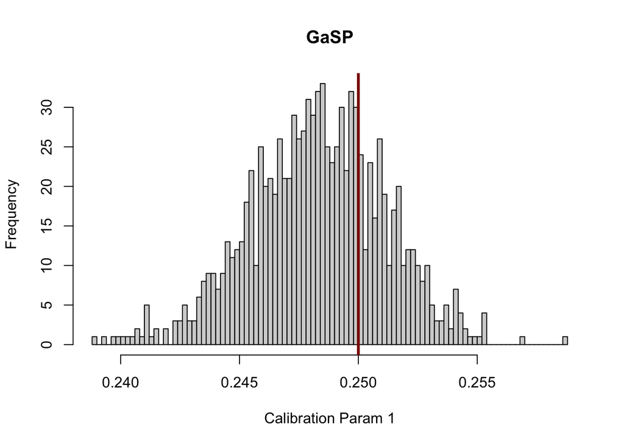

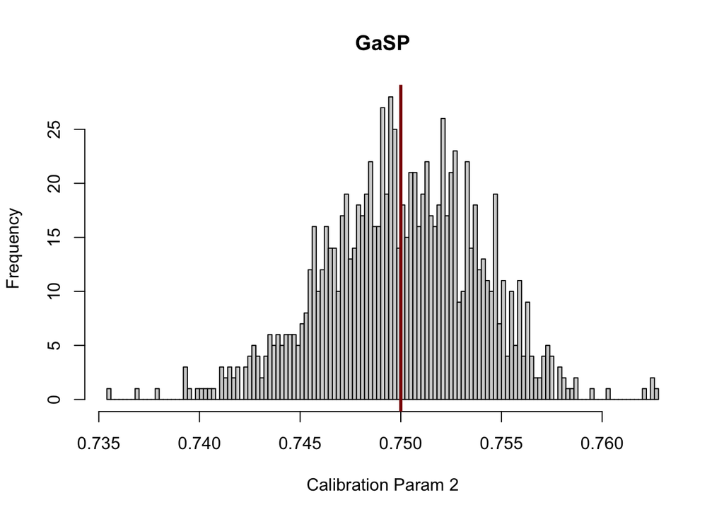

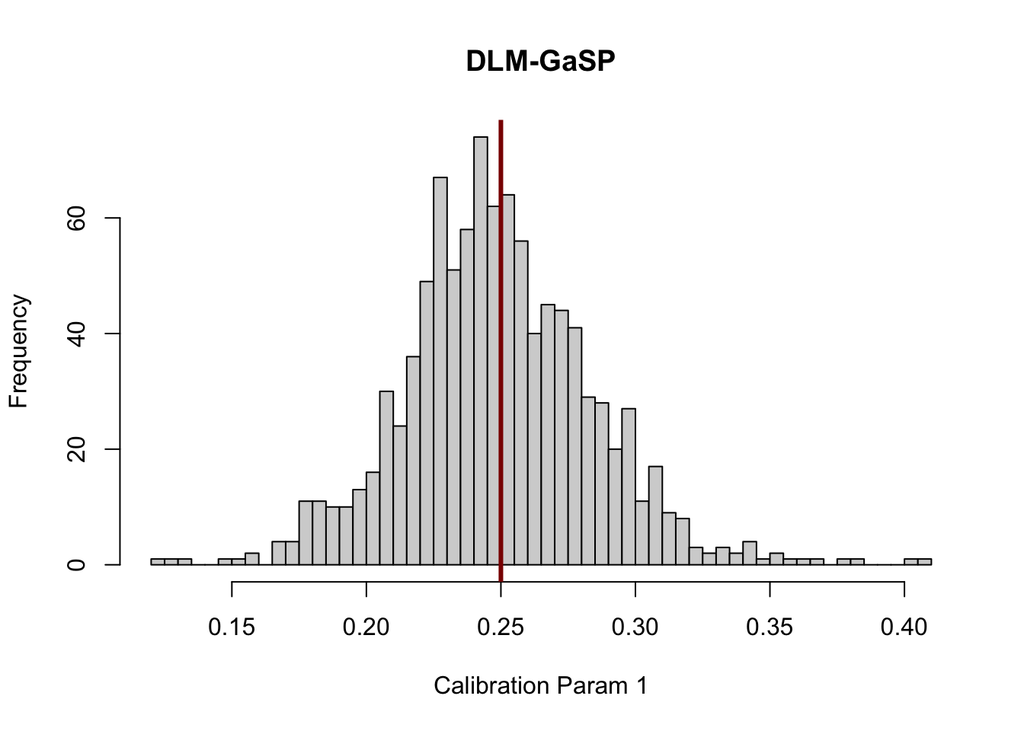

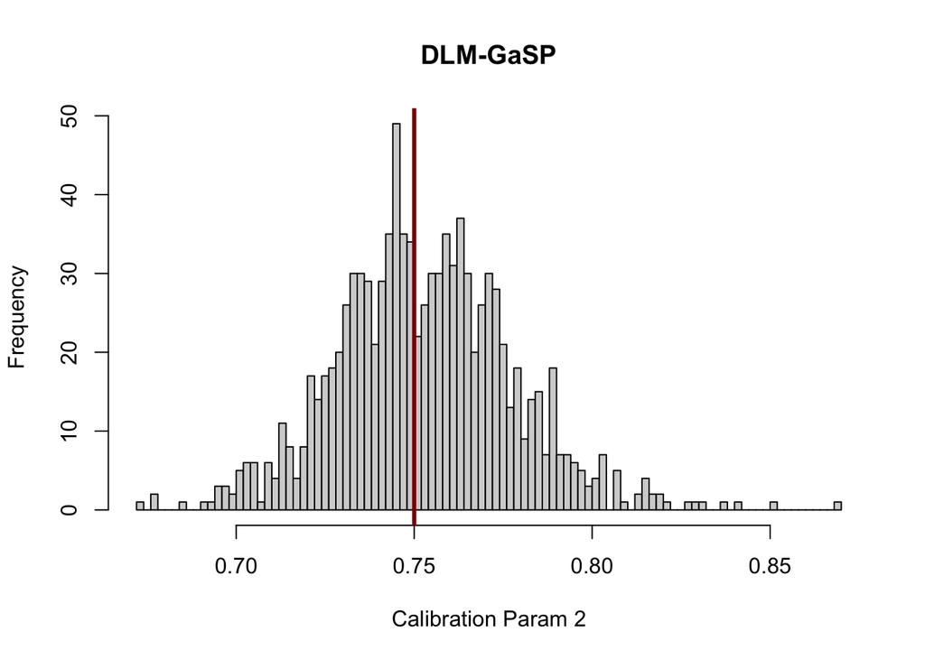

```
## [1] "GaSP Run Time:  13.32 minutes"
```

```
## [1] "DLM-GaSP Run Time:  25.11 seconds"
```

# Future Ideas for Spatio-Temporal GaSP